# STAT 380 Final Project

Spring 2019

Sanchit Goel and Daniel Walker

Due April 30, 2019

# Front matter

The front matter cleans up the R environment of any old data and values. Further we load all required packages to be able to run the code efficiently. Lastly we set a Random seed value for reproducibility puposes.

```r
# Cleaning up the R environment
rm(list = ls())

# Loading all the required packages
library (dplyr)
library (tidyr)
library (ggplot2)
library (caret)
library (readr)
library (tidyverse)
library (ggthemes)
library (stringr)
library (repr)
library (plotly)
library (corrplot)
library (caTools)
library (rpart)
library (rpart.plot)
library (mdsr)
library (reshape2)

# Setting a random seed, for code reproducibility
set.seed(380)
```

#### User Defined Function:

The function ‘replace_drop_na’ replaces all the dashes(i.e. ‘-’) with NA. Further drops any records with a NA value. This function was used on all datasets for data cleaning purposes.

```r
replace_drop_na <- function(arg_1) {
   arg_1[arg_1 == '-'] <- NA
   print(paste0("Pre-Cleaning Records: ", nrow(arg_1)))

  # Dropping NA values records
  result <- arg_1 %>%
  drop_na()

  print(paste0("Cleaned Records: ", nrow(result)))
  return(result)
}
```

# Loading and Cleaning the Datasets

### McDonalds Dataset

```r
mcd <- read.csv(file = "nutrition_facts_mcdonalds_menu.csv",
                header = TRUE, sep = ",")
mcd <- replace_drop_na(mcd)
```

```
[1] "Pre-Cleaning Records: 260"
[1] "Cleaned Records: 260"
```

```r
# Creating drink subset data
drinks.oz <- mcd[str_detect(mcd$Serving.Size, " fl oz.*"), ]
drinks.ml <- mcd[str_detect(mcd$Serving.Size, 'carton'), ]

# Converting ounces to mililiters
drinks.oz$Serving.Size <-
  round(as.numeric(gsub(" fl oz.*", "", drinks.oz$Serving.Size)) * 29.5735, 0)
drinks.ml$Serving.Size <-
  round(as.numeric(gsub(".*\\((.*)\\ ml).*", "\\1", drinks.ml$Serving.Size)), 0)

# Keeping the values and removing characters
food.g <- mcd[str_detect(mcd$Serving.Size, 'g'), ]
food.g$Serving.Size <-
  round(as.numeric(gsub(".*\\((.*)\\ g).*", "\\1", food.g$Serving.Size)), 0)

# Combining the drinks and food data
# Adding a feature to determine the type
cleaned_mcd <- rbind(drinks.oz, drinks.ml)
cleaned_mcd$Type <- rep("Drinks", nrow(cleaned_mcd))
food.g$Type <- rep("Food", nrow(food.g))
cleaned_mcd <- rbind(cleaned_mcd, food.g)

# Subsetting the dataset for analysis and joining purposes
keeps <- c("Item", "Calories", "Total.Fat", "Carbohydrates", "Dietary.Fiber",
           "Protein", "Type")
cleaned_mcd <- cleaned_mcd[keeps]
colnames(cleaned_mcd)[colnames(cleaned_mcd)=="Total.Fat"] <- "Total_Fat"
colnames(cleaned_mcd)[colnames(cleaned_mcd)=="Dietary.Fiber"] <- "Fiber"

# Converting character values into numeric values.
cleaned_mcd$Calories <-
  as.numeric(as.character(cleaned_mcd$Calories))
cleaned_mcd$Total_Fat <-
  as.numeric(as.character(cleaned_mcd$Total_Fat))
cleaned_mcd$Carbohydrates <-
  as.numeric(as.character(cleaned_mcd$Carbohydrates))
cleaned_mcd$Fiber <-
  as.numeric(as.character(cleaned_mcd$Fiber))
cleaned_mcd$Protein <-
  as.numeric(as.character(cleaned_mcd$Protein))
```

### Starbucks Dataset

```r
# Food Dataset
sbux_f <- read.csv(file = "nutrition_facts_starbucks_food_menu.csv",
                   header = TRUE, sep = ",")
sbux_f <- replace_drop_na(sbux_f)
```

```
[1] "Pre-Cleaning Records: 113"
[1] "Cleaned Records: 113"
```

```r
colnames(sbux_f)[colnames(sbux_f) == "ï..Food.Name"] <- "Item"
colnames(sbux_f)[colnames(sbux_f) == "Fat..g."] <- "Total_Fat"
colnames(sbux_f)[colnames(sbux_f) == "Carb...g."] <- "Carbohydrates"
colnames(sbux_f)[colnames(sbux_f) == "Fiber..g."] <- "Fiber"
colnames(sbux_f)[colnames(sbux_f) == "Protein..g."] <- "Protein"

# Drink Dataset
sbux_d <- read.csv(file = "nutrition_facts_starbucks_drink_menu.csv",
                   header = TRUE, sep = ",")
sbux_d <- replace_drop_na(sbux_d)
```

```
[1] "Pre-Cleaning Records: 177"
[1] "Cleaned Records: 92"
```

```r
sbux_d <- sbux_d %>%
  select(-one_of(c('Sodium')))
colnames(sbux_d)[colnames(sbux_d) == "X"] <- "Item"
colnames(sbux_d)[colnames(sbux_d) == "Fat..g."] <- "Total_Fat"
colnames(sbux_d)[colnames(sbux_d) == "Carb...g."] <- "Carbohydrates"
colnames(sbux_d)[colnames(sbux_d) == "Fiber..g."] <- "Fiber"

# Combining the drinks and food data
# Adding a feature to determine the type
sbux_d$Type <- rep("Drinks", nrow(sbux_d))
sbux_f$Type <- rep("Food", nrow(sbux_f))
cleaned_sbux <- rbind(sbux_f, sbux_d)

# Converting character values into numeric values.
cleaned_sbux$Calories <-
  as.numeric(as.character(cleaned_sbux$Calories))
cleaned_sbux$Total_Fat <-
  as.numeric(as.character(cleaned_sbux$Total_Fat))
cleaned_sbux$Carbohydrates <-
  as.numeric(as.character(cleaned_sbux$Carbohydrates))
cleaned_sbux$Fiber <-
  as.numeric(as.character(cleaned_sbux$Fiber))
cleaned_sbux$Protein <-
  as.numeric(as.character(cleaned_sbux$Protein))
```

### Starbucks Drinks Expanded Dataset

```r
drinks_expanded <- read.csv('starbucks_drink_menu_expanded.csv',
                            header = TRUE, sep = ",")

# The data contains trademarks and accent which are removed here
drinks_expanded$Beverage_category <- iconv(drinks_expanded$Beverage_category,
                                           "latin1", "ASCII", sub = "byte")
drinks_expanded$Beverage <- iconv(drinks_expanded$Beverage, "latin1",
                                  "ASCII", sub = "byte")
drinks_expanded$Beverage_prep <- iconv(drinks_expanded$Beverage_prep, "latin1",
                                       "ASCII", sub = "byte")

drinks_expanded$Beverage_category <-
  gsub('(<[a-z0-9]+>)', '', drinks_expanded$Beverage_category)
drinks_expanded$Beverage <-
  gsub('(<[a-z0-9]+>)', '', drinks_expanded$Beverage)
drinks_expanded$Beverage_prep <-
  gsub('(<[a-z0-9]+>)', '', drinks_expanded$Beverage_prep)

# Column names changed to conform to the earlier datasets
colnames(drinks_expanded)[colnames(drinks_expanded) == "Total.Fat..g."] <-
  "Total_Fat"
colnames(drinks_expanded)[colnames(drinks_expanded) == "Trans.Fat..g."] <-
  "Trasn_Fat"
colnames(drinks_expanded)[colnames(drinks_expanded) == "Saturated.Fat..g."] <-
  "Saturated_Fat"
colnames(drinks_expanded)[colnames(drinks_expanded) == "Sodium..mg."] <-
  "Sodium"
colnames(drinks_expanded)[colnames(drinks_expanded) == "Total.Carbohydrates..g."] <-
  "Total_Carbohydrates"
colnames(drinks_expanded)[colnames(drinks_expanded) == "Cholesterol..mg."] <-
  "Cholesterol"
colnames(drinks_expanded)[colnames(drinks_expanded) == "Dietary.Fibre..g."] <-
  "Dietary_Fibre"
colnames(drinks_expanded)[colnames(drinks_expanded) == "Sugars..g."] <-
  "Sugars"
colnames(drinks_expanded)[colnames(drinks_expanded) == "Protein..g."] <-
  "Protein"
colnames(drinks_expanded)[colnames(drinks_expanded) == "Vitamin.A....DV."] <-
  "Vitamin_A"
colnames(drinks_expanded)[colnames(drinks_expanded) == "Vitamin.C....DV."] <-
  "Vitamin_C"
colnames(drinks_expanded)[colnames(drinks_expanded) == "Calcium....DV."] <-
  "Calcium"
colnames(drinks_expanded)[colnames(drinks_expanded) == "Iron....DV."] <-
  "Iron"
colnames(drinks_expanded)[colnames(drinks_expanded) == "Caffeine..mg."] <-
  "Caffeine"

# Using Regular Expressiosn to remove % signs from the values.
# Converting character values into numeric values.
drinks_expanded$Vitamin_A <-
  gsub( "%", "", as.character(drinks_expanded$Vitamin_A))
drinks_expanded$Vitamin_A <-
  as.numeric(as.character(drinks_expanded$Vitamin_A))

drinks_expanded$Vitamin_C <-
  gsub( "%", "", as.character(drinks_expanded$Vitamin_C))
drinks_expanded$Vitamin_C <-
  as.numeric(as.character(drinks_expanded$Vitamin_C))

drinks_expanded$Calcium <-
  gsub( "%", "", as.character(drinks_expanded$Calcium))
drinks_expanded$Calcium <-
  as.numeric(as.character(drinks_expanded$Calcium))

drinks_expanded$Iron <-
  gsub( "%", "", as.character(drinks_expanded$Iron))
drinks_expanded$Iron <-
  as.numeric(as.character(drinks_expanded$Iron))

drinks_expanded$Caffeine <-
  gsub( "Varies", "", as.character(drinks_expanded$Caffeine))
drinks_expanded$Caffeine <-
  gsub( "varies", "", as.character(drinks_expanded$Caffeine))
drinks_expanded$Caffeine <-
  as.numeric(as.character(drinks_expanded$Caffeine))
drinks_expanded$Total_Fat <-
  as.numeric(as.character(drinks_expanded$Total_Fat))
```

```
NAs introduced by coercion
```

```r
drinks_expanded <-
  replace_drop_na(drinks_expanded)
```

```
[1] "Pre-Cleaning Records: 242"
[1] "Cleaned Records: 218"
```

### Joining the Mcdonalds and Starbucks Dataset

```r
# Joining the Food and Drink Menu for Starbucks and Mcdonalds
cleaned_sbux$Brand <- rep("Starbucks", nrow(cleaned_sbux))
cleaned_mcd$Brand <- rep("McDonalds", nrow(cleaned_mcd))
joined_data <- rbind(cleaned_mcd, cleaned_sbux)
```

### McDonalds Data Summary

```r
summary(cleaned_mcd)
```

```
                                      Item        Calories        Total_Fat       Carbohydrates
 1% Low Fat Milk Jug                    :  1   Min.   :   0.0   Min.   :  0.000   Min.   :  0.00
 Apple Slices                           :  1   1st Qu.: 210.0   1st Qu.:  2.375   1st Qu.: 30.00
 Bacon Buffalo Ranch McChicken          :  1   Median : 340.0   Median : 11.000   Median : 44.00
 Bacon Cheddar McChicken                :  1   Mean   : 368.3   Mean   : 14.165   Mean   : 47.35
 Bacon Clubhouse Burger                 :  1   3rd Qu.: 500.0   3rd Qu.: 22.250   3rd Qu.: 60.00
 Bacon Clubhouse Crispy Chicken Sandwich:  1   Max.   :1880.0   Max.   :118.000   Max.   :141.00
 (Other)                                :254
     Fiber          Protein          Type              Brand
 Min.   :0.000   Min.   : 0.00   Length:260         Length:260
 1st Qu.:0.000   1st Qu.: 4.00   Class :character   Class :character
 Median :1.000   Median :12.00   Mode  :character   Mode  :character
 Mean   :1.631   Mean   :13.34
 3rd Qu.:3.000   3rd Qu.:19.00
 Max.   :7.000   Max.   :87.00
```

### Starbucks Data Summary

```r
summary(cleaned_sbux)
```

```
                                         Item        Calories       Total_Fat     Carbohydrates
 Iced Coffee                               :  2   Min.   :  0.0   Min.   : 0.00   Min.   : 0.00
 Iced Espresso Classics - Caffe Mocha      :  2   1st Qu.:130.0   1st Qu.: 0.00   1st Qu.:21.00
 Iced Espresso Classics - Caramel Macchiato:  2   Median :250.0   Median : 7.00   Median :35.00
 Iced Espresso Classics - Vanilla Latte    :  2   Mean   :257.2   Mean   :10.06   Mean   :33.97
 Latte Macchiato                           :  2   3rd Qu.:380.0   3rd Qu.:18.00   3rd Qu.:45.00
 TazoÂ® Bottled Berry Blossom White        :  2   Max.   :650.0   Max.   :37.00   Max.   :80.00
 (Other)                                   :193
     Fiber           Protein           Type              Brand
 Min.   : 0.000   Min.   : 0.000   Length:205         Length:205
 1st Qu.: 0.000   1st Qu.: 1.000   Class :character   Class :character
 Median : 1.000   Median : 6.000   Mode  :character   Mode  :character
 Mean   : 1.771   Mean   : 8.185
 3rd Qu.: 3.000   3rd Qu.:13.000
 Max.   :21.000   Max.   :34.000
```

### Starbucks Drinks Expanded Summary

```r
summary(drinks_expanded)
```

```
 Beverage_category    Beverage         Beverage_prep         Calories       Total_Fat        Trasn_Fat
 Length:218         Length:218         Length:218         Min.   :  3.0   Min.   : 0.000   Min.   :0.0
 Class :character   Class :character   Class :character   1st Qu.:122.5   1st Qu.: 0.200   1st Qu.:0.1
 Mode  :character   Mode  :character   Mode  :character   Median :190.0   Median : 2.500   Median :0.5
                                                          Mean   :201.0   Mean   : 3.074   Mean   :1.4
                                                          3rd Qu.:270.0   3rd Qu.: 5.000   3rd Qu.:2.0
                                                          Max.   :510.0   Max.   :15.000   Max.   :9.0
 Saturated_Fat         Sodium       Total_Carbohydrates  Cholesterol    Dietary_Fibre       Sugars
 Min.   :0.00000   Min.   : 0.000   Min.   :  0.0       Min.   : 0.00   Min.   :0.000   Min.   : 0.00
 1st Qu.:0.00000   1st Qu.: 0.000   1st Qu.: 80.0       1st Qu.:21.00   1st Qu.:0.000   1st Qu.:19.00
 Median :0.00000   Median : 5.000   Median :127.5       Median :36.00   Median :0.000   Median :33.00
 Mean   :0.03945   Mean   : 6.674   Mean   :136.9       Mean   :37.16   Mean   :0.844   Mean   :33.94
 3rd Qu.:0.10000   3rd Qu.:10.000   3rd Qu.:180.0       3rd Qu.:52.50   3rd Qu.:1.000   3rd Qu.:44.00
 Max.   :0.30000   Max.   :40.000   Max.   :340.0       Max.   :90.00   Max.   :8.000   Max.   :84.00
    Protein         Vitamin_A       Vitamin_C          Calcium           Iron           Caffeine
 Min.   : 0.000   Min.   : 0.00   Min.   :  0.000   Min.   : 0.00   Min.   : 0.000   Min.   :  0.00
 1st Qu.: 4.000   1st Qu.: 4.00   1st Qu.:  0.000   1st Qu.:10.00   1st Qu.: 0.000   1st Qu.: 51.25
 Median : 6.000   Median : 8.00   Median :  0.000   Median :20.00   Median : 3.000   Median : 75.00
 Mean   : 7.305   Mean   :10.31   Mean   :  3.739   Mean   :21.68   Mean   : 8.041   Mean   : 89.93
 3rd Qu.:10.000   3rd Qu.:15.00   3rd Qu.:  0.000   3rd Qu.:30.00   3rd Qu.:10.000   3rd Qu.:143.75
 Max.   :20.000   Max.   :50.00   Max.   :100.000   Max.   :60.00   Max.   :50.000   Max.   :410.00
```

### Joined Data Summary

```r
summary(joined_data)
```

```
                                         Item        Calories        Total_Fat      Carbohydrates
 Chocolate Chip Cookie                     :  2   Min.   :   0.0   Min.   :  0.00   Min.   :  0.00
 Iced Coffee                               :  2   1st Qu.: 150.0   1st Qu.:  1.00   1st Qu.: 27.00
 Iced Espresso Classics - Caffe Mocha      :  2   Median : 300.0   Median :  9.00   Median : 40.00
 Iced Espresso Classics - Caramel Macchiato:  2   Mean   : 319.3   Mean   : 12.36   Mean   : 41.45
 Iced Espresso Classics - Vanilla Latte    :  2   3rd Qu.: 440.0   3rd Qu.: 20.00   3rd Qu.: 54.00
 Latte Macchiato                           :  2   Max.   :1880.0   Max.   :118.00   Max.   :141.00
 (Other)                                   :453
     Fiber           Protein          Type              Brand
 Min.   : 0.000   Min.   : 0.00   Length:465         Length:465
 1st Qu.: 0.000   1st Qu.: 2.00   Class :character   Class :character
 Median : 1.000   Median :10.00   Mode  :character   Mode  :character
 Mean   : 1.692   Mean   :11.07
 3rd Qu.: 3.000   3rd Qu.:17.00
 Max.   :21.000   Max.   :87.00
```

```r
# Freeing up Memory of redundant data
rm('mcd', 'sbux_d', 'keeps', 'drinks.ml', 'drinks.oz', 'food.g')
```

## McDonalds:

#### Calories Histogram

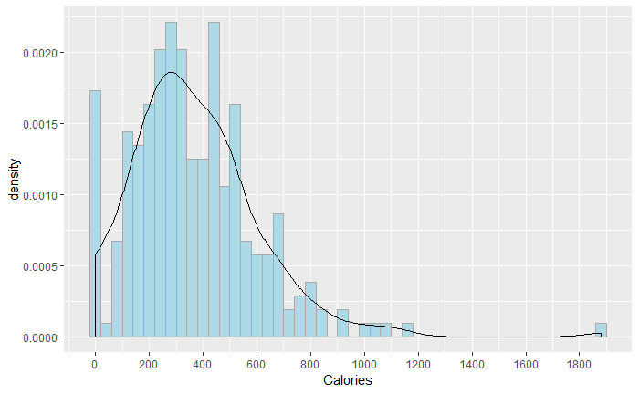

```r
options(repr.plot.height = 3, repr.plot.width = 6)
ggplot(cleaned_mcd, aes(x = Calories)) +
  geom_histogram(aes(y = ..density..),
                 fill = "lightblue", binwidth = 40, color = "darkgray") +
  scale_x_continuous(breaks = seq(min(cleaned_mcd$Calories),
                                  max(cleaned_mcd$Calories), by = 200)) +
  geom_density()
```

#### Calories BoxPlot

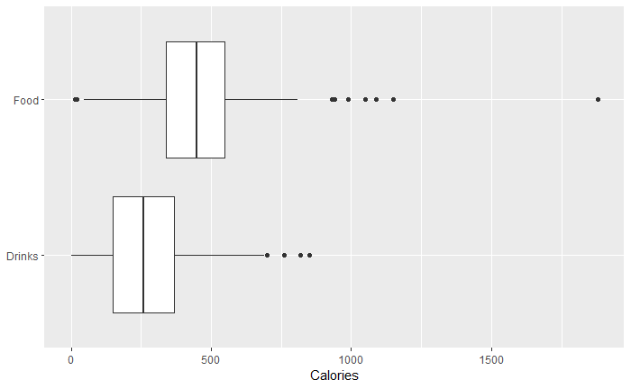

```r
options(repr.plot.height = 3, repr.plot.width = 6)
ggplot(cleaned_mcd, aes(x = reorder(Type, Calories), y = Calories)) +
  geom_boxplot() +
  coord_flip() +
  labs(x = NULL)
```

#### Correlation Plot

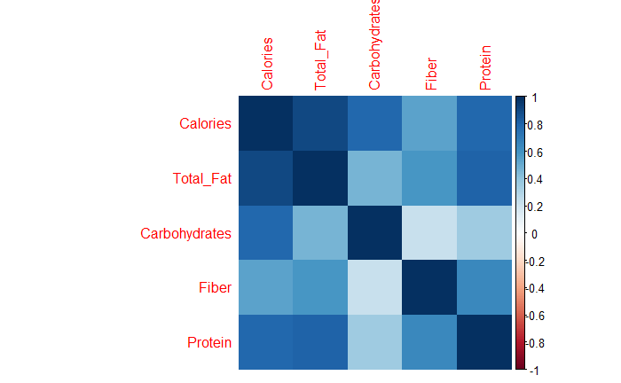

```r
cr <- cor(cleaned_mcd[, 2:6])
corrplot(cr, method = 'color')
```

```r
rm('cr')
```

#### Calories Vs Total Fat Scatter Plot

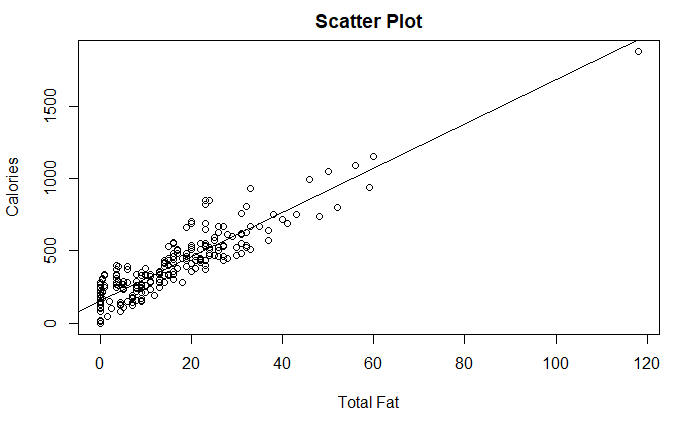

```r
plot(cleaned_mcd$Total_Fat, cleaned_mcd$Calories,
     main = "Scatter Plot", xlab = "Total Fat", ylab = "Calories")
abline(lm(cleaned_mcd$Calories ~ cleaned_mcd$Total_Fat))
```

#### Colries vs Protein Density Map

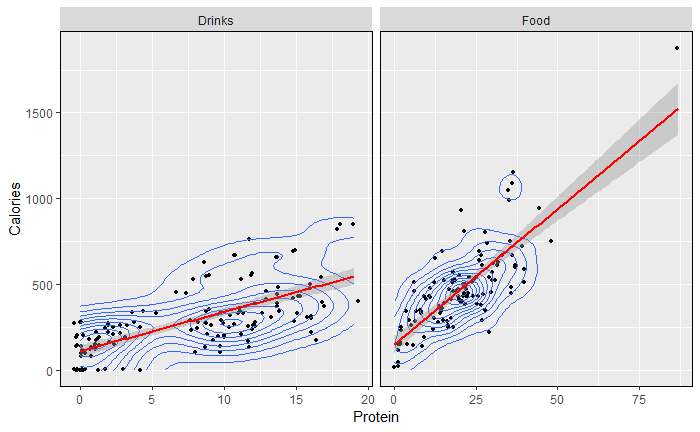

```r
options(repr.plot.height = 4, repr.plot.width = 6)
ggplot(cleaned_mcd, aes(y = Calories, x = Protein)) +
  geom_jitter(size = 1) +
  stat_density2d() +
  geom_smooth(method = 'lm', colour = 2) +
  facet_wrap( ~ Type, scales = "free_x") +
  theme(panel.border = element_rect(colour = 1, fill = NA))
```

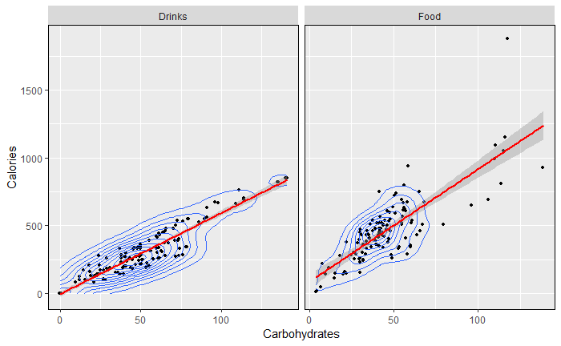

```r
options(repr.plot.height = 4, repr.plot.width = 6)
ggplot(cleaned_mcd, aes(y = Calories, x = Carbohydrates)) +
  geom_jitter(size = 1) +
  stat_density2d() +
  geom_smooth(method = 'lm', colour = 2) +
  facet_wrap( ~ Type, scales = "free_x") +
  theme(panel.border = element_rect(colour = 1, fill = NA))
```

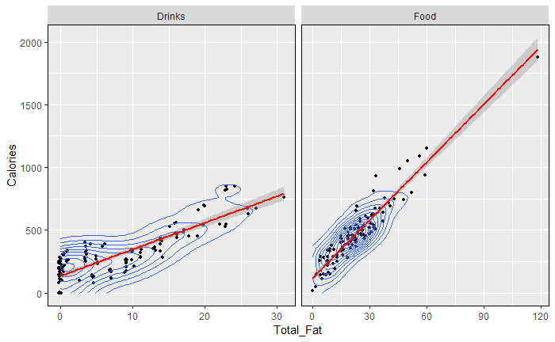

```r
options(repr.plot.height = 4, repr.plot.width = 6)
ggplot(cleaned_mcd, aes(y = Calories, x = Total_Fat)) +
  geom_jitter(size = 1) +
  stat_density2d() +
  geom_smooth(method = 'lm', colour = 2) +
  facet_wrap( ~ Type, scales = "free_x") +
  theme(panel.border = element_rect(colour = 1, fill = NA))
```

### Model Training

#### Splitting the dataset

```r
split <- sample.split(cleaned_mcd$Calories, SplitRatio = 0.80)
train <- subset(cleaned_mcd, split == "TRUE")
test <- subset(cleaned_mcd, split == "FALSE")
```

#### Linear Regression Model

```r
mcd_lm_model <-
  lm(Calories ~ Total_Fat + Protein + Carbohydrates, data = train)
summary(mcd_lm_model)
```

```
Call:
lm(formula = Calories ~ Total_Fat + Protein + Carbohydrates,
    data = train)

Residuals:
     Min       1Q   Median       3Q      Max
-20.6016  -2.4345   0.5948   3.6639  10.5681

Coefficients:
              Estimate Std. Error t value Pr(>|t|)
(Intercept)   -1.89785    0.77946  -2.435   0.0157 *
Total_Fat      9.01235    0.04769 188.991   <2e-16 ***
Protein        4.04957    0.05651  71.656   <2e-16 ***
Carbohydrates  3.98026    0.01488 267.459   <2e-16 ***
---
Signif. codes:  0 ‘***’ 0.001 ‘**’ 0.01 ‘*’ 0.05 ‘.’ 0.1 ‘ ’ 1

Residual standard error: 5.576 on 208 degrees of freedom
Multiple R-squared:  0.9995,    Adjusted R-squared:  0.9995
F-statistic: 1.454e+05 on 3 and 208 DF,  p-value: < 2.2e-16
```

#### Plots to explain the model

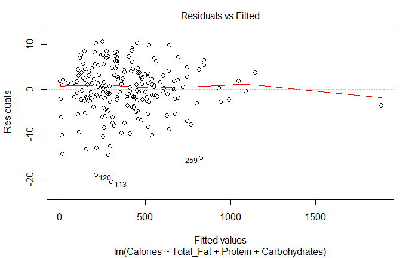

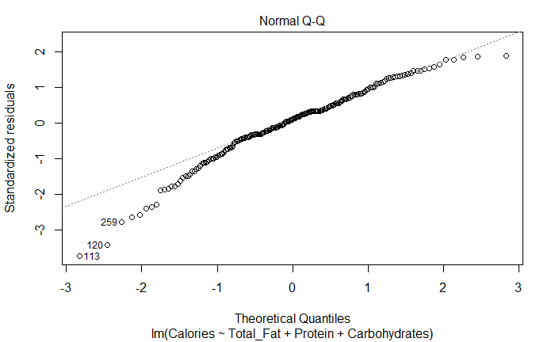

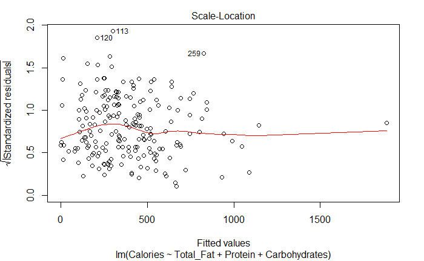

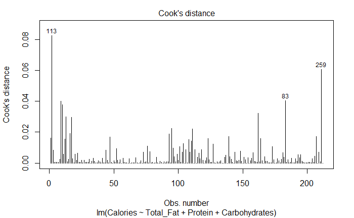

```r
plot(mcd_lm_model, which = 1:4)
```

#### Predictions vs Actual

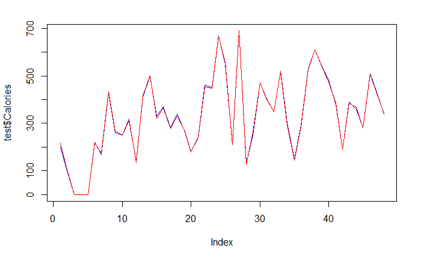

```r
predictions <- predict(mcd_lm_model, test)
plot(test$Calories, type = "l", lty = 1.8, col = "blue")
lines(predictions, type = "l", col = "red")
```

#### Future Predictions

```r
predict(mcd_lm_model, data.frame(Total_Fat = 20,
                                 Protein = 18, Carbohydrates = 33))
```

```
       1
382.5898
```

#### Decision Tree

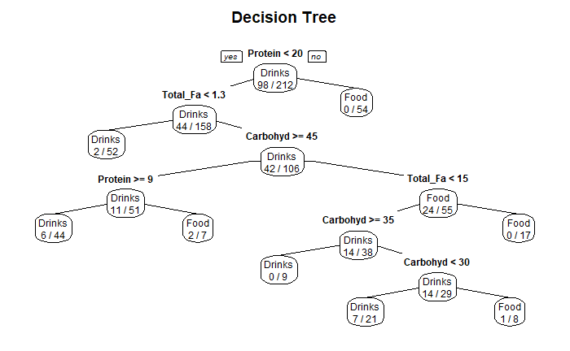

```r
mcd_dt_model <- rpart(Type ~ Calories + Total_Fat + Protein + Carbohydrates,
                      data = train)
prp(mcd_dt_model, type = 1, extra = 3, main = "Decision Tree")
```

```r
predictions <-
  data.frame(data = factor(predict(mcd_dt_model, test, type = "class")),
             type = "prediction")
real <- data.frame(data = factor(test$Type), type = "real")
conf_data <- rbind(predictions, real)

# Check if the levels are identical
identical(levels(conf_data[conf_data$type == "prediction", 1]),
          levels(conf_data[conf_data$type == "real", 1]))
```

```
[1] TRUE
```

```r
confusionMatrix(conf_data[conf_data$type == "prediction", 1],
                conf_data[conf_data$type == "real",1],
                dnn = c("Prediction", "Reference"))
```

```
Confusion Matrix and Statistics

          Reference
Prediction Drinks Food
    Drinks     26    5
    Food        2   15

               Accuracy : 0.8542
                 95% CI : (0.7224, 0.9393)
    No Information Rate : 0.5833
    P-Value [Acc > NIR] : 5.221e-05

                  Kappa : 0.6934

 Mcnemar's Test P-Value : 0.4497

            Sensitivity : 0.9286
            Specificity : 0.7500
         Pos Pred Value : 0.8387
         Neg Pred Value : 0.8824
             Prevalence : 0.5833
         Detection Rate : 0.5417
   Detection Prevalence : 0.6458
      Balanced Accuracy : 0.8393

       'Positive' Class : Drinks
```

```r
# Freeing up Memory of redundant data
rm('predictions', 'real', 'conf_data', 'split', 'test', 'train')
```

## Starbucks:

#### Calories Histogram

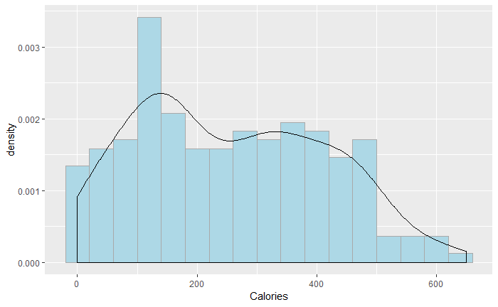

```r
options(repr.plot.height = 3, repr.plot.width = 6)
ggplot(cleaned_sbux, aes(x = Calories)) +
  geom_histogram(aes(y = ..density..), fill = "lightblue",
                 binwidth = 40, color = "darkgray") +
  scale_x_continuous(breaks = seq(min(cleaned_sbux$Calories),
                                  max(cleaned_sbux$Calories), by = 200)) +
  geom_density()
```

#### Calories BoxPlot

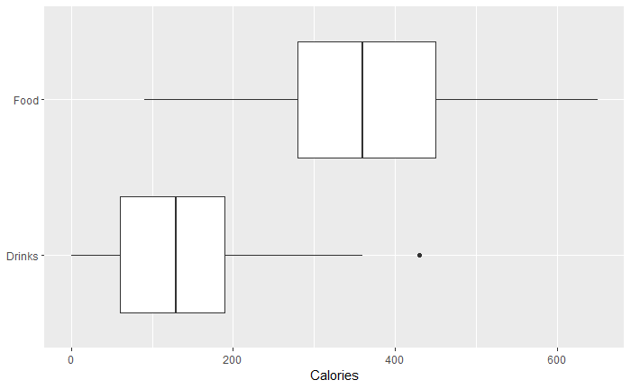

```r
options(repr.plot.height = 3, repr.plot.width = 6)
ggplot(cleaned_sbux, aes(x = reorder(Type, Calories), y = Calories)) +
  geom_boxplot() +
  coord_flip() +
  labs(x = NULL)
```

#### Correlation Plot

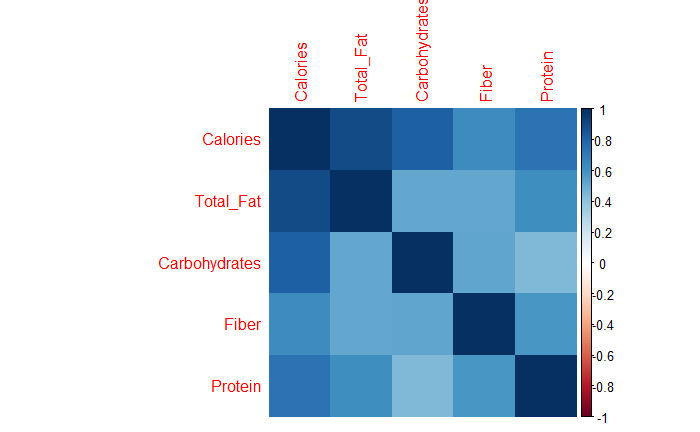

```r
cr <- cor(cleaned_sbux[, 2:6])
corrplot(cr, method = 'color')
```

```r
rm('cr')
```

#### Calories Vs Total Fat Scatter Plot

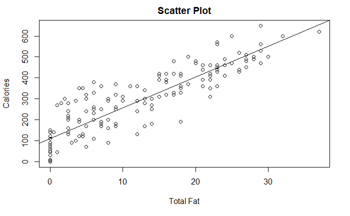

```r
plot(cleaned_sbux$Total_Fat, cleaned_sbux$Calories,
     main = "Scatter Plot", xlab = "Total Fat", ylab = "Calories")
abline(lm(cleaned_sbux$Calories ~ cleaned_sbux$Total_Fat))
```

#### Colries vs Protein Density Map

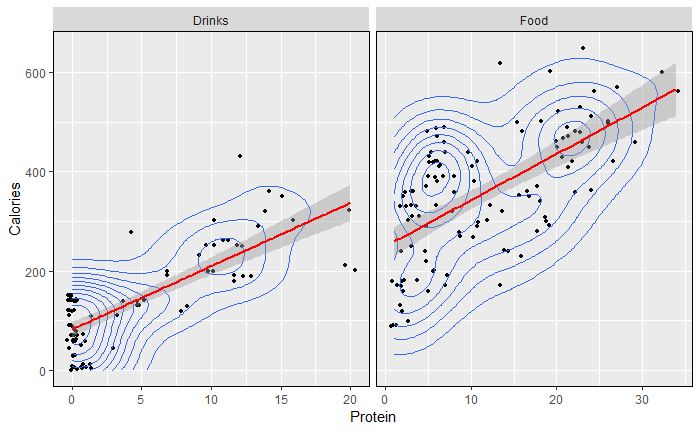

```r
options(repr.plot.height = 4, repr.plot.width = 6)
ggplot(cleaned_sbux, aes(y = Calories, x = Protein)) +
  geom_jitter(size = 1) +
  stat_density2d() +
  geom_smooth(method = 'lm', colour = 2) +
  facet_wrap( ~ Type, scales = "free_x") +
  theme(panel.border = element_rect(colour = 1, fill = NA))
```

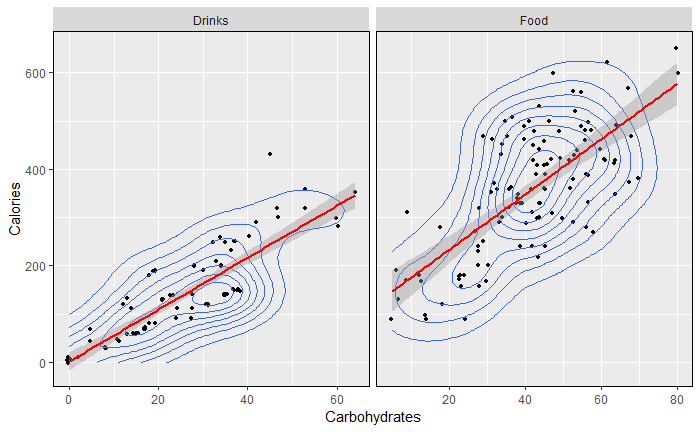

```r
options(repr.plot.height = 4, repr.plot.width = 6)
ggplot(cleaned_sbux, aes(y = Calories, x = Carbohydrates)) +
  geom_jitter(size = 1) +
  stat_density2d() +
  geom_smooth(method = 'lm', colour = 2) +
  facet_wrap( ~ Type, scales = "free_x") +
  theme(panel.border = element_rect(colour = 1, fill = NA))
```

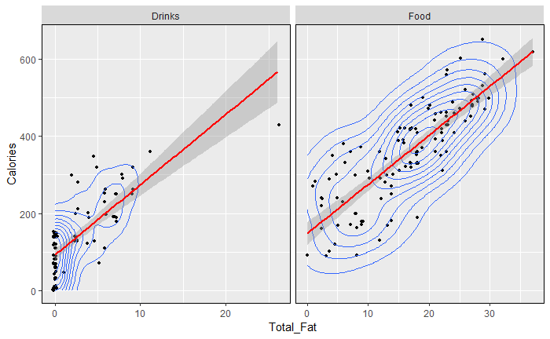

```r
options(repr.plot.height = 4, repr.plot.width = 6)
ggplot(cleaned_sbux, aes(y = Calories, x = Total_Fat)) +
  geom_jitter(size = 1) +
  stat_density2d() +
  geom_smooth(method = 'lm', colour = 2) +
  facet_wrap( ~ Type, scales = "free_x") +
  theme(panel.border = element_rect(colour = 1, fill = NA))
```

### Model Training

#### Splitting the dataset

```r
split <- sample.split(cleaned_sbux$Calories, SplitRatio = 0.80)
train <- subset(cleaned_sbux, split == "TRUE")
test <- subset(cleaned_sbux, split == "FALSE")
```

#### Linear Regression Model

```r
sbux_lm_model <- lm(Calories ~ Total_Fat + Protein + Carbohydrates,
                    data = train)
summary(sbux_lm_model)
```

```
Call:
lm(formula = Calories ~ Total_Fat + Protein + Carbohydrates,
    data = train)

Residuals:
    Min      1Q  Median      3Q     Max
-36.215  -3.720   0.701   3.903  34.053

Coefficients:
              Estimate Std. Error t value Pr(>|t|)
(Intercept)    1.41258    1.50035   0.942    0.348
Total_Fat      8.96025    0.09783  91.588   <2e-16 ***
Protein        3.96744    0.11408  34.779   <2e-16 ***
Carbohydrates  3.91334    0.04676  83.689   <2e-16 ***
---
Signif. codes:  0 ‘***’ 0.001 ‘**’ 0.01 ‘*’ 0.05 ‘.’ 0.1 ‘ ’ 1

Residual standard error: 9.016 on 164 degrees of freedom
Multiple R-squared:  0.9969,    Adjusted R-squared:  0.9969
F-statistic: 1.775e+04 on 3 and 164 DF,  p-value: < 2.2e-16
```

#### Plots to explain the model

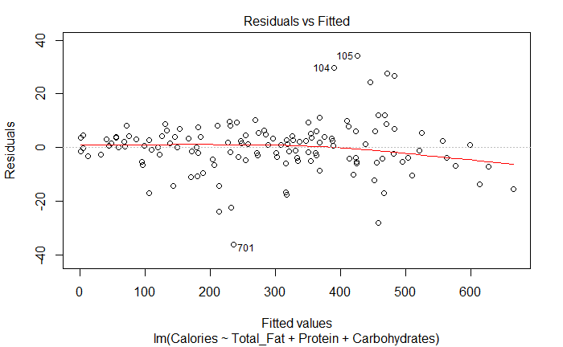

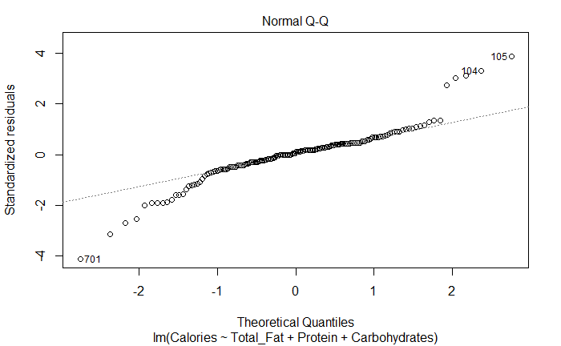

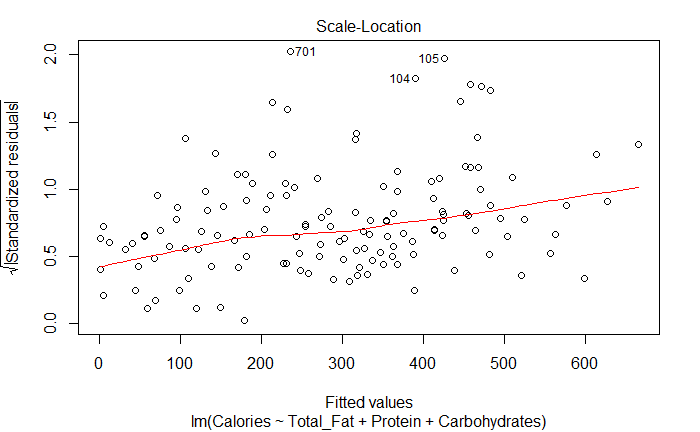

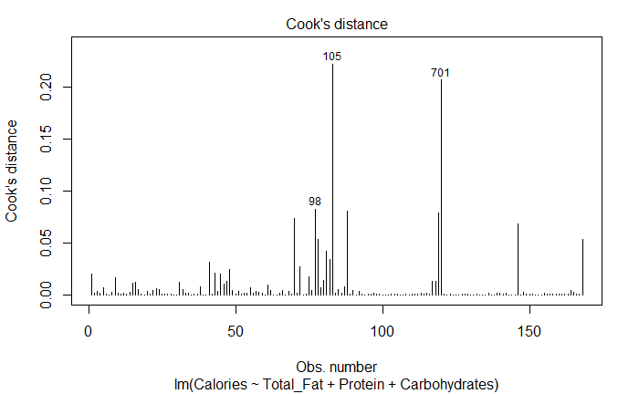

```r
plot(sbux_lm_model, which = 1:4)
```

#### Predictions vs Actual

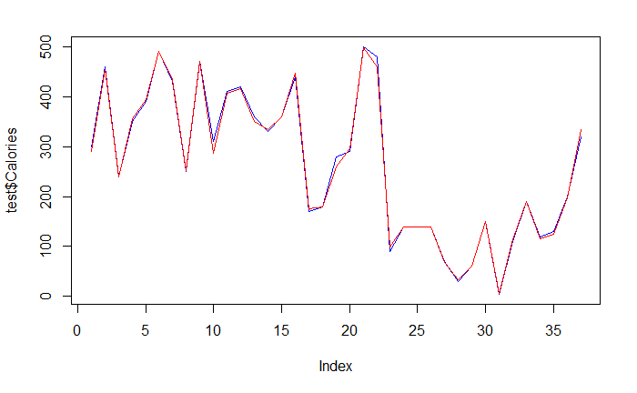

```r
predictions <- predict(sbux_lm_model, test)
plot(test$Calories, type = "l", lty = 1.8, col = "blue")
lines(predictions, type = "l", col = "red")
```

#### Future Predictions

```r
predict(sbux_lm_model, data.frame(Total_Fat = 20, Protein = 18, Carbohydrates = 33))
```

```
       1
381.1717
```

#### Decision Tree

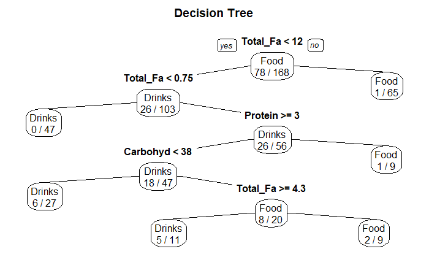

```r
sbux_dt_model <- rpart(Type ~ Calories + Total_Fat + Protein + Carbohydrates,
                       data = train)
prp(sbux_dt_model, type = 1, extra = 3, main = "Decision Tree")
```

```r
predictions <-
  data.frame(data = factor(predict(sbux_dt_model, test, type="class")),
             type = "prediction")
real <- data.frame(data = factor(test$Type), type = "real")
conf_data <- rbind(predictions, real)

# Check if the levels are identical
identical(levels(conf_data[conf_data$type == "prediction", 1]),
          levels(conf_data[conf_data$type == "real", 1]))
```

```
[1] TRUE
```

```r
confusionMatrix(conf_data[conf_data$type == "prediction", 1],
                conf_data[conf_data$type == "real",1],
                dnn = c("Prediction", "Reference"))
```

```
Confusion Matrix and Statistics

          Reference
Prediction Drinks Food
    Drinks     13    4
    Food        1   19

               Accuracy : 0.8649
                 95% CI : (0.7123, 0.9546)
    No Information Rate : 0.6216
    P-Value [Acc > NIR] : 0.00109

                  Kappa : 0.7243

 Mcnemar's Test P-Value : 0.37109

            Sensitivity : 0.9286
            Specificity : 0.8261
         Pos Pred Value : 0.7647
         Neg Pred Value : 0.9500
             Prevalence : 0.3784
         Detection Rate : 0.3514
   Detection Prevalence : 0.4595
      Balanced Accuracy : 0.8773

       'Positive' Class : Drinks
```

```r
# Freeing up Memory of redundant data
rm('predictions', 'real', 'conf_data', 'split', 'test', 'train')
```

## Joined Data:

#### Calories Histogram

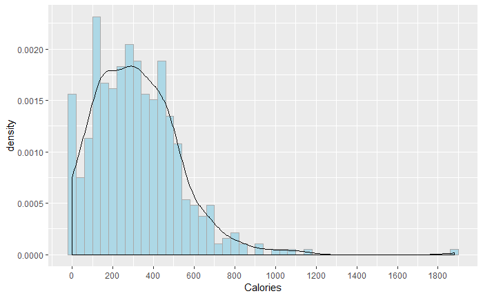

```r
options(repr.plot.height = 3, repr.plot.width = 6)
ggplot(joined_data, aes(x = Calories)) +
  geom_histogram(aes(y = ..density..),
                 fill = "lightblue", binwidth = 40, color = "darkgray") +
  scale_x_continuous(breaks = seq(min(joined_data$Calories),
                                  max(joined_data$Calories), by = 200)) +
  geom_density()
```

#### Calories BoxPlot

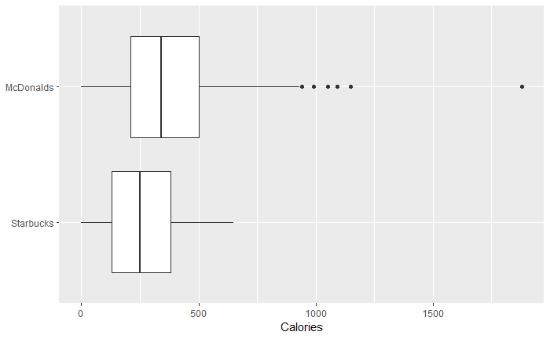

```r
options(repr.plot.height = 3, repr.plot.width = 6)
ggplot(joined_data, aes(x = reorder(Brand, Calories), y = Calories)) +
  geom_boxplot() +
  coord_flip() +
  labs(x = NULL)
```